# Using Models 1

Analysis of Environmental Data

Adrienne Dunk

# load data

```r
require(here) #load here into session
here() #check directory
```

```
## [1] "C:/Users/adrienne.dunk/Documents/environmental_data"
```

```r
catrate <- read.csv(here("data", "catrate.csv"))
head(catrate)
```

|  | pond | success | years | cat.rate |
| --- | --- | --- | --- | --- |
| 1 | 2 | 5 | 7 | 0.2857143 |
| 2 | 3 | 5 | 7 | 0.2857143 |
| 3 | 4 | 6 | 7 | 0.1428571 |
| 4 | 5 | 4 | 7 | 0.4285714 |
| 5 | 6 | 0 | 7 | 1.0000000 |
| 6 | 7 | 1 | 4 | 0.7500000 |

```r
summary(catrate)
```

```
##       pond       success          years          cat.rate
##  Min.   : 2   Min.   :0.000   Min.   :1.000   Min.   :0.1429
##  1st Qu.: 5   1st Qu.:1.000   1st Qu.:3.000   1st Qu.:0.2857
##  Median : 8   Median :2.000   Median :4.000   Median :0.4286
##  Mean   : 8   Mean   :2.538   Mean   :4.692   Mean   :0.5394
##  3rd Qu.:11   3rd Qu.:5.000   3rd Qu.:7.000   3rd Qu.:0.7500
##  Max.   :14   Max.   :6.000   Max.   :7.000   Max.   :1.0000
```

# Q1 Catastrophic Rate Histogram

Create a histogram of salamander reproduction catastrophic rates.

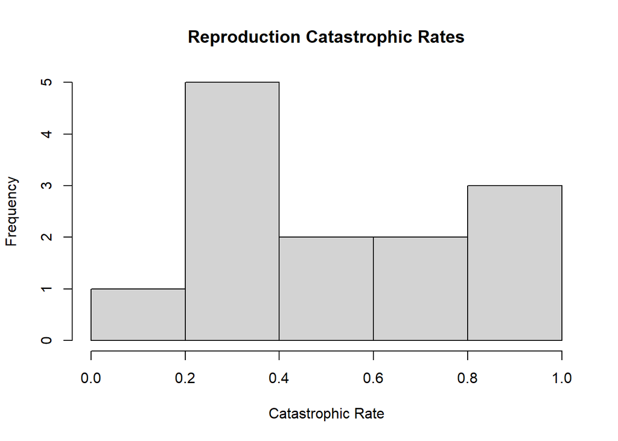

```r
hist(catrate$cat.rate, main = "Reproduction Catastrophic Rates", xlab = "Catastrophic Rate")
```

# Q2-4: Normality Test

### Q2: Conduct a Shapiro-Wilk test for the salamander catastrophic rates.

```r
shapiro.test(catrate$cat.rate)
```

```
##
##  Shapiro-Wilk normality test
##
## data:  catrate$cat.rate
## W = 0.86202, p-value = 0.04097
```

```r
#p-value of 0.04
```

### Q3: What is the null for the Shapiro Test

The null value for the Shapiro Test is that the population is normally distributed.

### Q4: Are the catastrophic rates normally-distributed?

No, the low p-value indicates that we should reject the null. These rates are not sampled from a normally distributed population.

# Q5-7: T-Test 1

### Q5: Run the t-test that the catastrphic rate is different from the pond late-refilling rate.

```r
t.test(catrate$cat.rate, mu = 2/7)
```

```
##
##  One Sample t-test
##
## data:  catrate$cat.rate
## t = 2.9595, df = 12, p-value = 0.01193
## alternative hypothesis: true mean is not equal to 0.2857143
## 95 percent confidence interval:
##  0.3526250 0.7261295
## sample estimates:
## mean of x
## 0.5393773
```

### Q6: State the null in plain English

The null hypothesis is that the average of the catastrophe rate and the average of late-refilling ponds are statistically the same.

### Q7: Is this a one- or two-tailed test

This is a two-tailed test because we only asked if they were the same or different and we did not specify a direction (greater/less than).

# Q8-10: T-Test 2

### Q8: What is the p-value from the Q5 t-test?

The p-value is 0.01 which means that the catastrophe rate average and the pond late-refilling rates are not the same. With a p-value of 0.01, we have 1% chance of saying that they are different when they are actually the same.

### Q9: What are the confidence intervals from the Q5 t-test?

The 95% confidence intervals were 0.353 to 0.726. The interval does not include 0.

### Q10: Did you reject the null? If so, why?

Yes, I reject the null that the mean of the catastrophe rates are equal to the rates of the late-refilling rates. I reject it because the null is less than the pre-determined rejection rate of 0.05. Also the confidence interval does not contain 0 indicating that there is sa true difference.

# Q11-13 Wilcoxon Test 1

### Q11: Conduct a one-sample Wilcoxon rank sum test that the catastrphic rate is different than the pond late-refilling rate.

```r
wilcox.test(catrate$cat.rate, mu = 2/7)
```

```
##
##  Wilcoxon signed rank test with continuity correction
##
## data:  catrate$cat.rate
## V = 85, p-value = 0.006275
## alternative hypothesis: true location is not equal to 0.2857143
```

### Q13: Did you reject the null, if so, why?

I rejected the null because the p-value of the Wilcox test was below my rejection rate of 0.05.

# Q14-15: Test Comparison

### Q14: Compare the conclusions you could draw from the t-test and Wilcox test.

Both tests allow you to draw the same conclusion that the pond late-refilling rate is different than the catastrphic rate.

### Q15: Which test was more appropriate for these data?

The Wilcox test was more appropriate for these data because the catastrophic rates were not normally distributed.

# Q16-17: Flippers - Normality Tests

### Q16: conduct tests of normality for the flipper lengths of Chinstrap and Adelie penguins.

```r
require(palmerpenguins)
penguin_dat <- droplevels(subset(penguins, species != "Gentoo"))
summary(penguin_dat)
```

```
##       species          island    bill_length_mm  bill_depth_mm
##  Adelie   :152   Biscoe   : 44   Min.   :32.10   Min.   :15.50
##  Chinstrap: 68   Dream    :124   1st Qu.:37.75   1st Qu.:17.50
##                  Torgersen: 52   Median :40.60   Median :18.40
##                                  Mean   :41.91   Mean   :18.37
##                                  3rd Qu.:45.95   3rd Qu.:19.10
##                                  Max.   :58.00   Max.   :21.50
##                                  NA's   :1       NA's   :1
##  flipper_length_mm  body_mass_g       sex           year
##  Min.   :172.0     Min.   :2700   female:107   Min.   :2007
##  1st Qu.:187.0     1st Qu.:3400   male  :107   1st Qu.:2007
##  Median :191.0     Median :3700   NA's  :  6   Median :2008
##  Mean   :191.8     Mean   :3711                Mean   :2008
##  3rd Qu.:196.0     3rd Qu.:3988                3rd Qu.:2009
##  Max.   :212.0     Max.   :4800                Max.   :2009
##  NA's   :1         NA's   :1
```

```r
dat_adelie <- subset(penguin_dat, species == "Adelie")
dat_chinstrap <- subset(penguin_dat, species == "Chinstrap")
shapiro.test(dat_adelie$flipper_length_mm) #is normal
```

```
##
##  Shapiro-Wilk normality test
##
## data:  dat_adelie$flipper_length_mm
## W = 0.99339, p-value = 0.72
```

```r
shapiro.test(dat_chinstrap$flipper_length_mm) #is normal
```

```
##
##  Shapiro-Wilk normality test
##
## data:  dat_chinstrap$flipper_length_mm
## W = 0.98891, p-value = 0.8106
```

### Q17: Interpret the test results.

The Shapiro-Wilk test indicates that the Adelie and Chinstrap flipper lengths are each normally distributed. The p-values are 0.72 and 0.81 respectively. Given this, we cannot reject the null hypthesis that the sample populations are normally distributed.

# Q18: Flippers - Histograms

Create a single figure of two side-by-side histograms of the flipper lengths of the penguin species.

```r
require(here)
png(filename = here("Penguin_Flippers.png"), width = 800, height = 600)

par(mfrow = c(1,2))
hist(dat_adelie$flipper_length_mm,
     main = "Adelie",
     xlab = "Flipper Length (mm)")
hist(dat_chinstrap$flipper_length_mm,
     main = "Chinstrap",
     xlab = "Flipper Length (mm)")

dev.off
```

[output not shown]

# Q19-20: Flippers T-test

Conduct a two-sample t-test of the alternative hypothesis that the Adelie have different flipper lengths than the Chinstrap penguins. ### Q19: The alternative hypothesis of the test is that the average flipper length of Adelie penguins is different than the average flipper length of Chinstrap penguins. This is a two-tailed test because we are not hypothesizing about the direction of any possible difference.

### Q20:

```r
t.test(penguin_dat$flipper_length_mm ~ penguin_dat$species, alternative = c("two.sided"))
```

```
##
##  Welch Two Sample t-test
##
## data:  penguin_dat$flipper_length_mm by penguin_dat$species
## t = -5.7804, df = 119.68, p-value = 6.049e-08
## alternative hypothesis: true difference in means between group Adelie and group Chinstrap is not equal to 0
## 95 percent confidence interval:
##  -7.880530 -3.859244
## sample estimates:
##    mean in group Adelie mean in group Chinstrap
##                189.9536                195.8235
```